# Temperature prediction with Nearest Neighbors

```python
import sklearn
import pandas as pd
import seaborn
```

# 📦 Data provisioning

The weather data is gathered from open-meteo, including data for the temperature, humidity, wind speed, etc. The dataset includes data from 2020-2025

```python
needed_columns = ["time", "temperature_2m (°C)", "relative_humidity_2m (%)", "pressure_msl (hPa)", "precipitation (mm)"]
data = pd.read_csv('eindhoven-weather.csv', usecols=needed_columns)
data = data.dropna(subset=needed_columns)
```

# 📃 Sample the data

```python
data.sample(10)
```

|  | time | temperature_2m (°C) | relative_humidity_2m (%) | precipitation (mm) | pressure_msl (hPa) |
| --- | --- | --- | --- | --- | --- |
| 40555 | 2024-08-16T19:00 | 20.3 | 86 | 0.0 | 1014.4 |
| 17745 | 2022-01-09T09:00 | 3.7 | 88 | 0.0 | 998.4 |
| 43977 | 2025-01-06T09:00 | 11.5 | 75 | 0.0 | 983.6 |
| 27456 | 2023-02-18T00:00 | 10.4 | 91 | 0.0 | 1023.3 |
| 14623 | 2021-09-01T07:00 | 15.0 | 81 | 0.0 | 1028.3 |
| 23383 | 2022-09-01T07:00 | 17.0 | 62 | 0.0 | 1020.4 |
| 29980 | 2023-06-03T04:00 | 12.2 | 75 | 0.0 | 1021.2 |
| 19966 | 2022-04-11T22:00 | 10.1 | 58 | 0.0 | 1012.8 |
| 37819 | 2024-04-24T19:00 | 6.8 | 73 | 0.0 | 1008.8 |
| 43591 | 2024-12-21T07:00 | 6.8 | 93 | 0.0 | 1015.0 |

# 🛠️ Preprocessing

## 🎯 Target Variable

Machine learning algorithms work exclusively with numerical data and generate numerical outputs. Therefore, the first step is to ensure that our target variable is numeric. In our case, we need to categorize the temperature data to make it compatible with the Nearest Neighbors algorithm.

This categorization allows our model to use numerical labels instead of raw temperature values, making it suitable for the Nearest Neighbors approach while maintaining a structured representation of temperature ranges.

A new column named temp_category is created, which assigns a numerical category to each temperature value in the temperature_2m (°C) column. The categorization follows these rules:

```python
def categorize_temperature(temp):
    if temp < 5:
        return "Cold ( < 5°C )"
    elif 5 <= temp < 15:
        return "Moderate (5 - 15°C)"
    else:
        return "Warm ( >= 15°C )"

data["temp_category"] = data["temperature_2m (°C)"].apply(categorize_temperature)
```

```python
from sklearn import preprocessing
encoder = preprocessing.LabelEncoder()
data["temp_id"] = encoder.fit_transform(data["temp_category"])

data.sample(10)
```

|  | time | temperature_2m (°C) | relative_humidity_2m (%) | precipitation (mm) | pressure_msl (hPa) | temp_category | temp_id |
| --- | --- | --- | --- | --- | --- | --- | --- |
| 38204 | 2024-05-10T20:00 | 16.8 | 69 | 0.0 | 1022.7 | Warm ( >= 15°C ) | 2 |
| 13587 | 2021-07-20T03:00 | 12.7 | 91 | 0.0 | 1021.4 | Moderate (5 - 15°C) | 1 |
| 1293 | 2020-02-23T21:00 | 6.5 | 74 | 0.0 | 1020.4 | Moderate (5 - 15°C) | 1 |
| 17188 | 2021-12-17T04:00 | 5.6 | 100 | 0.0 | 1039.6 | Moderate (5 - 15°C) | 1 |
| 18490 | 2022-02-09T10:00 | 7.8 | 85 | 0.0 | 1025.7 | Moderate (5 - 15°C) | 1 |
| 21591 | 2022-06-18T15:00 | 33.4 | 32 | 0.0 | 1013.7 | Warm ( >= 15°C ) | 2 |
| 35970 | 2024-02-07T18:00 | 4.4 | 90 | 0.0 | 1005.0 | Cold ( < 5°C ) | 0 |
| 10691 | 2021-03-21T11:00 | 7.6 | 66 | 0.0 | 1024.2 | Moderate (5 - 15°C) | 1 |
| 34524 | 2023-12-09T12:00 | 7.9 | 88 | 0.3 | 1003.4 | Moderate (5 - 15°C) | 1 |
| 13159 | 2021-07-02T07:00 | 13.9 | 82 | 0.0 | 1016.9 | Moderate (5 - 15°C) | 1 |

### 💡 Feature Selection

To optimize our model, we must select only those features that best explain the variance in the target variable. In our case, since we are categorizing temperatures, we need to identify which features have distinguishable patterns across different temperature categories.

For classification problems, a useful way to assess feature importance is by examining how well different features separate the temperature categories. A helpful visualization for this is a box plot, which can show the distribution of each feature across different temperature groups.

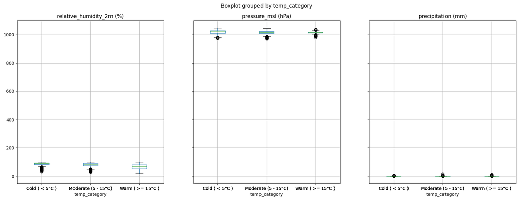

```python
candidates = needed_columns[2:]
numeric_candidates = data[candidates].columns.tolist()

plot = data.boxplot(column=numeric_candidates, by="temp_category", figsize=(20,7), layout=(1,len(candidates)))
```

Based on these findings, the selected features are stored in the variable X, and the target variable (temperature) is stored in y.

```python
params = ["pressure_msl (hPa)", "relative_humidity_2m (%)"]
target = "temp_id"
X = data[params]
y = data[target]
```

### 🪓 Splitting into train/test

80% of the data is used for training, and 20% for testing

```python
from sklearn.model_selection import train_test_split
X_train, X_test, y_train, y_test = train_test_split(X, y, test_size=0.2)
print("There are in total", len(X), "observations, of which", len(X_train), "are now in the train set, and", len(X_test), "in the test set.")
```

```
There are in total 44810 observations, of which 35848 are now in the train set, and 8962 in the test set.
```

### ⚖️ Scaling

Transforming the data using `Euclidean Distance` and `standard deviation`

[figure not shown]

```python
from sklearn.preprocessing import StandardScaler
scaler = StandardScaler()
scaler.fit(X_train)
X_train = scaler.transform(X_train)
X_test = scaler.transform(X_test)

plot = seaborn.scatterplot(x=X_train[:,0], y=X_train[:,1], hue=y_train, palette="viridis")
plot.set(xlabel=X.columns[0], ylabel=X.columns[1], title="Distance between temperatures")
plot.legend(data["temp_category"].unique(), title="Temperature category")
```

# 🧬 Modelling

Nearest Neighbour will be used

```python
from sklearn.neighbors import KNeighborsClassifier
model = KNeighborsClassifier(n_neighbors=49)
model.fit(X_train, y_train)
pred = model.predict(X_test)

from sklearn.metrics import accuracy_score
score = accuracy_score(pred, y_test)
print("Accuracy:", score)
```

```
Accuracy: 0.6272037491631333
```

# Prediction

First we need the last data point, to be able to predict the next data point

```python
latest_observation = data.iloc[-1][params].values.reshape(1, -1)
latest_observation_scaled = scaler.transform(latest_observation)
```

```python
predicted_category = model.predict(latest_observation_scaled)[0]

category_mapping = {
    0: "< 0 degrees",
    1: "0 ≤ temperature < 5",
    2: "5 ≤ temperature < 10",
    3: "≥ 10 degrees"
}
predicted_temperature_range = category_mapping[predicted_category]

print(f"Predicted temperature range for 2025-02-11: {predicted_temperature_range}")
```

[output not shown]

[figure not shown]